# writeup R

Yawen Hu, yawenhu@umich.edu

November 24, 2020

##### Libraries:

```r
# libraries: ------------------------------------------------------------------
library(MatchIt)
library(survey)
library(tidyverse)
library(ggplot2)
library(tableone)
```

- `MatchIt`: The package has `matchit` function, which is used to perform propensity score matching.
- `survey`: `svydesign` and `svyglm` functions in this package are used to perform logistic regression with sample weights.
- `tidyverse`: The package used for data I/O and preparation.
- `ggplot2`: The package used for data visualization.
- `tableone`: The package used for balance generating balance checking tables.

### Step 1 - Pre-evaluating before matching

```r
# data: -----------------------------------------------------------------------
nhanes = read_delim("nhanes.csv", delim = ",")
nhanes = nhanes %>%
  mutate(
    diabete = as.factor(diabete),
    heart_attack = as.factor(heart_attack),
    gender = ifelse(gender == 2, 1, 0),
  )
```

```r
var = c("relative_heart_attack", "gender", "age", "race", "edu", "annual_income",
        "bmi", "smoke_life", "phy_vigorous", "phy_moderate", "blood_press",
        "blood_press2", "hyper_med", "high_chol", "meadial_access", "cover_hc",
        "health_diet", "year_smoke", "year_hyper")
match_tab1 = CreateTableOne(vars=var, strata="diabete", data=nhanes, test=FALSE)
print(match_tab1, smd = TRUE)
```

```
##                                    Stratified by diabete
##                                     0             1             SMD
##   n                                  4429           836
##   relative_heart_attack (mean (SD))  0.12 (0.32)   0.17 (0.38)   0.159
##   gender (mean (SD))                 0.53 (0.50)   0.45 (0.50)   0.156
##   age (mean (SD))                   49.12 (17.64) 63.52 (12.17)  0.950
##   race (mean (SD))                   3.27 (1.25)   3.23 (1.27)   0.033
##   edu (mean (SD))                    3.57 (1.22)   3.28 (1.33)   0.230
##   annual_income (mean (SD))          9.02 (4.19)   8.41 (4.10)   0.148
##   bmi (mean (SD))                   29.34 (7.17)  32.23 (7.80)   0.386
##   smoke_life (mean (SD))             0.40 (0.49)   0.50 (0.50)   0.193
##   phy_vigorous (mean (SD))           0.25 (0.43)   0.17 (0.38)   0.192
##   phy_moderate (mean (SD))           0.43 (0.50)   0.35 (0.48)   0.177
##   blood_press (mean (SD))            0.32 (0.47)   0.69 (0.46)   0.794
##   blood_press2 (mean (SD))           0.26 (0.44)   0.58 (0.49)   0.700
##   hyper_med (mean (SD))              0.29 (0.45)   0.67 (0.47)   0.838
##   high_chol (mean (SD))              0.30 (0.46)   0.60 (0.49)   0.622
##   meadial_access (mean (SD))         0.79 (0.41)   0.92 (0.27)   0.382
##   cover_hc (mean (SD))               0.83 (0.37)   0.91 (0.28)   0.232
##   health_diet (mean (SD))            1.97 (1.02)   1.87 (1.00)   0.101
##   year_smoke (mean (SD))            13.62 (20.05) 22.64 (24.81)  0.400
##   year_hyper (mean (SD))             3.85 (8.29)  11.40 (13.26)  0.682
```

- We use the pre-matched data to do balance check between treatment and control groups. We computed the average standardized differences (SMD) for each covariates. From the table, we can find that, for most of the covariates, there are pretty large differences between treatment and control groups.

### Step 2 - Propensity score estimation

```r
## Logistic regression for treatment ~ pretreatment:
design_ps = svydesign( ids = ~1, weights = ~weight, data = nhanes )
ps_mod = svyglm(diabete ~ relative_heart_attack + gender + age + race + edu
                + annual_income + bmi + smoke_life + phy_vigorous + phy_moderate
                + blood_press + blood_press2 + hyper_med + hbq_med + high_chol
                + meadial_access + cover_hc + health_diet + year_smoke + year_hyper,
                family = binomial(),
                design = design_ps)
## Get the propensity score:
p_score = predict(ps_mod, type = "response")
```

- We estimate the propensity score by running a logistic model, where the outcome variable `diabete` is a binary variable indicating treatment status and all the other covariates are used as predictors. In order to include sample weights in the model, we also used `svydesign` and `svyglm` functions in the `survey` package.
- With the logistic model, we can calculate the propensity score, which is simply the predicted probability of being treated.
- The distribution of the generated propensity scores in treatment/control groups are shown below. From figure 1, we can find that there are some overlaps between the two groups, which guarantees the propensity score matching sample.

**Click to view `code for figure 1`.**

```r
cap1 = "**figure 1.** *Propensity score distribution by Treated/Control Groups*"
ps = data.frame(
  p_score = ps_mod$fitted.values,
  Diabete = ifelse(ps_mod$model$diabete == 1, "Diabetes", "No Diabetes")
)

fig1 = ps %>%
  ggplot( aes(x = p_score) ) +
  geom_histogram( aes(color = Diabete, fill = Diabete),
                      position = "identity", bins = 30, alpha = 0.3) +
  scale_color_manual(values = c("#00AFBB", "#E7B800")) +
  scale_fill_manual(values = c("#00AFBB", "#E7B800")) +
  xlab("Propensity Score") +
  ylab("Frequency") +
  theme_bw()
```

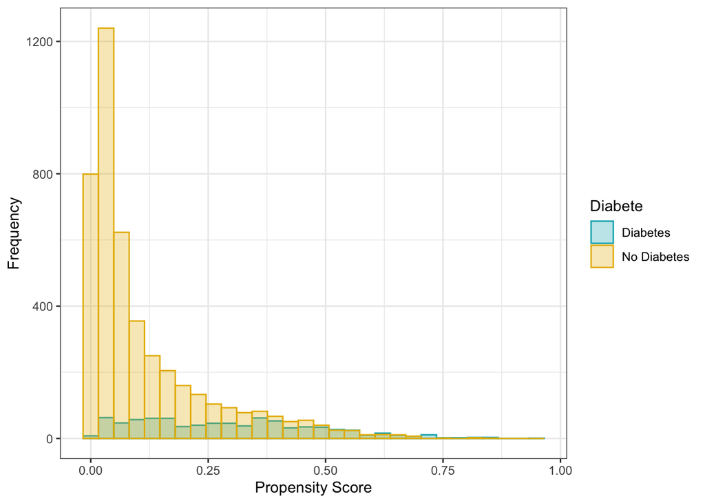

**figure 1.** *Propensity score distribution by Treated/Control Groups*

```r
cap1 = "**figure 1.** *Propensity score distribution by Treated/Control Groups*"
print(fig1)
```

### Step 3 - Propensity score match

```r
nhanes_ps = nhanes %>% mutate( p_score = p_score)
match_mod = matchit(ps_mod,
                    distance = 'logit',
                    method = "nearest",
                    caliper = .2,
                    ratio = 1,
                    data = nhanes_ps,
                    replace = FALSE)
ps_match = match.data(match_mod)
```

- We can use propensity score matching to generate a sub-sample, which minimizes the covariates’ difference between treatment group and control group. The `matchit` function in `MatchIt` package can estimate the propensity score internally and match observations based on different methods. The method we chose in this tutorial example is nearest neighborhood.

### Step 4 - Balance Checking after matching

```r
var = c("relative_heart_attack", "gender", "age", "race", "edu", "annual_income",
        "bmi", "smoke_life", "phy_vigorous", "phy_moderate", "blood_press",
        "blood_press2", "hyper_med", "high_chol", "meadial_access", "cover_hc",
        "health_diet", "year_smoke", "year_hyper")
match_tab = CreateTableOne(vars=var, strata="diabete", data=ps_match, test=FALSE)
print(match_tab, smd = TRUE)
```

```
##                                    Stratified by diabete
##                                     0             1             SMD
##   n                                   824           824
##   relative_heart_attack (mean (SD))  0.18 (0.38)   0.17 (0.38)   0.016
##   gender (mean (SD))                 0.47 (0.50)   0.45 (0.50)   0.024
##   age (mean (SD))                   63.61 (14.51) 63.38 (12.19)  0.017
##   race (mean (SD))                   3.22 (1.09)   3.22 (1.28)  <0.001
##   edu (mean (SD))                    3.35 (1.29)   3.29 (1.33)   0.045
##   annual_income (mean (SD))          8.46 (4.11)   8.42 (4.09)   0.010
##   bmi (mean (SD))                   31.76 (7.78)  31.98 (7.37)   0.029
##   smoke_life (mean (SD))             0.50 (0.50)   0.50 (0.50)   0.007
##   phy_vigorous (mean (SD))           0.18 (0.38)   0.17 (0.38)   0.016
##   phy_moderate (mean (SD))           0.35 (0.48)   0.35 (0.48)   0.003
##   blood_press (mean (SD))            0.66 (0.48)   0.69 (0.46)   0.067
##   blood_press2 (mean (SD))           0.54 (0.50)   0.58 (0.49)   0.078
##   hyper_med (mean (SD))              0.64 (0.48)   0.67 (0.47)   0.064
##   high_chol (mean (SD))              0.59 (0.49)   0.60 (0.49)   0.020
##   meadial_access (mean (SD))         0.91 (0.28)   0.92 (0.27)   0.026
##   cover_hc (mean (SD))               0.92 (0.27)   0.91 (0.29)   0.030
##   health_diet (mean (SD))            1.85 (1.03)   1.87 (1.00)   0.019
##   year_smoke (mean (SD))            22.12 (25.10) 22.46 (24.67)  0.014
##   year_hyper (mean (SD))            10.07 (12.39) 11.12 (12.98)  0.083
```

- By using the same method of the pre-evaluation mentioned in Step 1, we can do the balance checking again using the matched sample. From the table, it’s obvious to observe significant decreases in SMD of all covariates. The difference between treatment group and control group became insignificant with the matched sample.

### Step 5 - Comparison between pre_match data and matched data

#### Result tables

##### Proportion of Heat Attack with Pre-matched Group

**Click to view `code for Table 1`.**

```r
cap2 = "**Table 1.** *Proportion of Heat Attack with Pre-matched Group*"
tab_pre_mt = nhanes %>%
  group_by(diabete, heart_attack) %>%
  summarize(n = sum(weight), .groups = "drop_last") %>%
  mutate(
    prop = 100*(n / sum(n))
  ) %>%
  transmute(
    `Heart Attack` = ifelse(heart_attack == 1, "YES", "NO"),
    Diabetes = ifelse(diabete == 1, "Diabetes", "NoDiabetes"),
    prop = sprintf('%10.0f (%4.2f%%)', n, prop)
  ) %>%
  pivot_wider(
    id_cols = `Heart Attack`,
    names_from = Diabetes,
    values_from = prop
  ) %>%
  knitr::kable(format = 'html', caption = cap2) %>%
  kableExtra::kable_styling("striped", full_width = TRUE) %>%
  kableExtra::add_header_above(
    header = c("Proportion of Heat Attack with Pre-matched Group" = 3)
  )
```

**Table 1.** *Proportion of Heat Attack with Pre-matched Group*

| Proportion of Heat Attack with Pre-matched Group Heart Attack | Proportion of Heat Attack with Pre-matched Group NoDiabetes | Proportion of Heat Attack with Pre-matched Group Diabetes |
| --- | --- | --- |
| NO | 195463600 (97.80%) | 22122559 (85.24%) |
| YES | 4398495 (2.20%) | 3830884 (14.76%) |

##### Proportion of Heat Attack with Matched Group

**Click to view `code for Table2`.**

```r
cap3 = "**Table 2.** *Proportion of Heat Attack with Matched Group*"
tab_mt = ps_match %>%
  group_by(diabete, heart_attack) %>%
  summarize(n = sum(weight), .groups = "drop_last") %>%
  mutate(
    prop = 100*(n / sum(n))
  ) %>%
  transmute(
    `Heart Attack` = ifelse(heart_attack == 1, "YES", "NO"),
    Diabetes = ifelse(diabete == 1, "Diabetes", "NoDiabetes"),
    prop = sprintf('%10.0f (%4.2f%%)', n, prop)
  ) %>%
  pivot_wider(
    id_cols = `Heart Attack`,
    names_from = Diabetes,
    values_from = prop
  ) %>%
  knitr::kable(format = 'html', caption = cap3) %>%
  kableExtra::kable_styling("striped", full_width = TRUE) %>%
  kableExtra::add_header_above(
    header = c("Proportion of Heat Attack with Matched Group" = 3)
  )
```

**Table 2.** *Proportion of Heat Attack with Matched Group*

| Proportion of Heat Attack with Matched Group Heart Attack | Proportion of Heat Attack with Matched Group NoDiabetes | Proportion of Heat Attack with Matched Group Diabetes |
| --- | --- | --- |
| NO | 28113901 (94.22%) | 21930140 (85.24%) |
| YES | 1723725 (5.78%) | 3796836 (14.76%) |

##### t-test

```r
heart_attack_d = ps_match %>%
  filter(diabete == 1)

heart_attack_nd = ps_match %>%
  filter(diabete == 0)

print(t.test(as.numeric(heart_attack_d$heart_attack), as.numeric(heart_attack_nd$heart_attack)))
```

```
##
##  Welch Two Sample t-test
##
## data:  as.numeric(heart_attack_d$heart_attack) and as.numeric(heart_attack_nd$heart_attack)
## t = 4.5391, df = 1510.1, p-value = 6.098e-06
## alternative hypothesis: true difference in means is not equal to 0
## 95 percent confidence interval:
##  0.03790290 0.09559224
## sample estimates:
## mean of x mean of y
##  1.133495  1.066748
```

- With the t-test result, we reject the hypothesis that the mean value of heart attack in two groups are equal. So with the matched data, the heart attack rate in diabete group is still higher than the non-diabete group.

### Step 6 - Inverse propensity score weighting

- We also can generate the inverse propensity score weight to reduce the bias between treatment and control groups.

**Click to view `code for Table3`.**

```r
cap4 = "**Table 3.** *Proportion of Heat Attack with Inverse Propensity Weight*"
invert = nhanes_ps %>%
  select(diabete, heart_attack, weight, p_score) %>%
  mutate(
    inverse_wt = ifelse(diabete == 1, 1/p_score, 1/(1-p_score)),
    new_wt = weight * inverse_wt
  ) %>%
  group_by(diabete, heart_attack) %>%
  summarize(n = sum(new_wt), .groups = "drop_last") %>%
  mutate(
    prop = 100*(n / sum(n))
  ) %>%
  transmute(
    `Heart Attack` = ifelse(heart_attack == 1, "YES", "NO"),
    Diabetes = ifelse(diabete == 1, "Diabetes", "NoDiabetes"),
    prop = sprintf('%10.0f (%4.2f%%)', n, prop)
  ) %>%
  pivot_wider(
    id_cols = `Heart Attack`,
    names_from = Diabetes,
    values_from = prop
  ) %>%
  knitr::kable(format = 'html', caption = cap4) %>%
  kableExtra::kable_styling("striped", full_width = TRUE) %>%
  kableExtra::add_header_above(
    header = c("Proportion of Heat Attack with Inverse Propensity Weight" = 3)
  )
```

**Table 3.** *Proportion of Heat Attack with Inverse Propensity Weight*

| Proportion of Heat Attack with Inverse Propensity Weight Heart Attack | Proportion of Heat Attack with Inverse Propensity Weight NoDiabetes | Proportion of Heat Attack with Inverse Propensity Weight Diabetes |
| --- | --- | --- |
| NO | 220194075 (97.38%) | 210007533 (94.17%) |
| YES | 5934506 (2.62%) | 13009816 (5.83%) |